# Tutorial de Clustering: K-means y Clustering Jerárquico (NCI60)

**Autor:** Arturo Vargas Espinosa

# Introducción

En todos los proyectos anteriores de este portafolio se trabajó con **aprendizaje supervisado**: había una variable de salida (el ingreso, si alguien tiene prestaciones, el sector económico) y el modelo aprendía a predecirla a partir de las variables explicativas. En este tutorial el problema es distinto: no hay ninguna variable de salida. Solo se tienen observaciones con sus variables, y lo que se quiere es descubrir si existen **grupos** de observaciones parecidas entre sí. A esto se le llama **aprendizaje no supervisado**, y a la técnica para encontrar esos grupos se le llama **clustering**.

El tutorial sigue los pasos de los talleres C3.3 (*K-means clustering*) y C3.4 (*Hierarchical clustering*) y está dividido en tres partes:

1. **K-means desde cero con datos sintéticos.** Se programa el algoritmo paso por paso (asignación aleatoria, centroides, actualización) sobre un dataset creado con `make_blobs`, para entender exactamente qué hace y por qué el resultado depende de la asignación inicial.
2. **K-means con datos reales (NCI60).** Se aplica `KMeans` de scikit-learn a un dataset de expresión genética de 64 líneas celulares de cáncer, primero con los datos originales y después con PCA como preprocesamiento, y se interpretan los clusters comparándolos con el tipo de cáncer y con los genes que más los separan.
3. **Clustering jerárquico con NCI60.** Se construyen dendrogramas con distintas métricas de disimilitud (euclideana y correlación) y distintos métodos de *linkage* (complete y average), y se compara lo que encuentra cada uno.

En cada paso se explica qué se va a hacer, por qué, y qué es lo que muestran los resultados, para que cualquier persona pueda reproducir el tutorial y entender los puntos más importantes del tema.

# Metodología

### ¿Qué es clustering?

Clustering es un conjunto de técnicas para encontrar **grupos (clusters)** en un conjunto de datos, de forma que:

- las observaciones de un **mismo** grupo sean muy **parecidas** entre sí, y
- las observaciones de **distintos** grupos sean muy **diferentes**.

Como no hay una variable de salida, no existe una respuesta "correcta" contra la cual medir el resultado, como en clasificación. Por eso en clustering pesa mucho la **interpretación**: hay que revisar si los grupos que se encontraron tienen sentido para el problema.

### K-means clustering

K-means divide las observaciones en exactamente $K$ grupos que no se traslapan (cada observación pertenece a un solo grupo), y hay que decirle de antemano cuántos grupos queremos. La idea es que un "buen" agrupamiento es aquel en el que la **variación dentro de cada grupo** (*within-cluster variation*) es lo más pequeña posible, es decir, en el que las observaciones de cada grupo difieren lo menos posible entre sí.

Usando la distancia euclideana al cuadrado, la variación dentro del grupo $C_k$ es:

$$W(C_k) = \frac{1}{|C_k|} \sum_{i, i' \in C_k} \sum_{j=1}^{p} (x_{ij} - x_{i'j})^2 = 2 \sum_{i \in C_k} \sum_{j=1}^{p} (x_{ij} - \bar{x}_{kj})^2$$

y K-means busca los grupos que minimizan la suma de todas:

$$\min_{C_1, \dots, C_K} \sum_{k=1}^{K} W(C_k)$$

(Ecuaciones hechas con Claude)

La segunda forma de la ecuación es la que hace práctico al algoritmo: comparar cada par de observaciones es lo mismo (salvo el 2) que comparar cada observación contra el **centroide** de su grupo $\bar{x}_k$, que es el vector con el promedio de cada variable. Por eso se usa la distancia euclideana **al cuadrado**: permite usar promedios en vez de medianas para los centroides (con distancias absolutas saldría *k-medians*), se vuelve una multiplicación de matrices sencilla, y le da más peso a las desviaciones grandes.

Encontrar el mínimo exacto es casi imposible (hay muchísimas formas de repartir $n$ observaciones en $K$ grupos), así que se usa un algoritmo que encuentra un **óptimo local**:

1. Asignar aleatoriamente un número del 1 al $K$ a cada observación (cluster inicial).
2. Repetir hasta que las asignaciones dejen de cambiar:
   - Calcular el centroide de cada cluster (el promedio de las $p$ variables de sus observaciones).
   - Asignar cada observación al cluster cuyo centroide le quede más cerca (distancia euclideana al cuadrado).

En cada iteración el objetivo nunca sube, por eso el algoritmo siempre termina. Pero como solo garantiza un óptimo **local**, el resultado depende de la asignación aleatoria inicial (**estocasticidad**): con otra asignación inicial se puede llegar a otro resultado. Por eso en la práctica el algoritmo se corre varias veces desde asignaciones distintas y se queda la solución con el objetivo más pequeño.

### PCA como preprocesamiento

Cuando hay muchísimas variables (como los 6,830 genes de NCI60) y pocas observaciones (64), las distancias entre observaciones se llenan de ruido: cada gen aporta un poquito de diferencia aleatoria y la estructura real se diluye. Con **PCA** se transforman los datos a unos cuantos **componentes principales** que concentran la mayor parte de la variación, y el clustering se hace sobre esos componentes. Esto reduce el ruido y además permite graficar los datos en 2 dimensiones (PC1 vs PC2, etc.) para ver los clusters.

### Hierarchical clustering

El clustering jerárquico no necesita que se le diga $K$ de antemano. En lugar de eso construye un **dendrograma**, un árbol que representa todos los agrupamientos posibles, desde $n$ clusters (cada observación sola) hasta 1 (todas juntas).

- Cada **hoja** del árbol es una observación.
- Conforme se sube en el árbol, las hojas se van uniendo en ramas: se unen las observaciones (o grupos) que son parecidas entre sí.
- Entre **más abajo** se unen dos ramas, **más parecidas** son. El eje vertical representa la disimilitud.
- Si se **corta** el árbol a cierta altura, las ramas que quedan debajo del corte son los clusters. Cortar más arriba da menos clusters, más abajo da más.

Se le llama jerárquico porque los clusters que salen al cortar a cierta altura siempre están **anidados** dentro de los que salen al cortar más arriba. Esto es una desventaja cuando los grupos reales no están anidados (por ejemplo, personas de 3 países con 2 tipos de profesión: los 3 grupos de país no tienen por qué estar dentro de los 2 grupos de profesión).

El algoritmo (aglomerativo) es:

1. Empezar con las $n$ observaciones, cada una como su propio cluster, y calcular la disimilitud entre todos los pares.
2. Para $i = n, n-1, \dots, 2$: unir el par de clusters con menor disimilitud (la altura de la unión en el dendrograma es esa disimilitud) y recalcular las disimilitudes con los $i - 1$ clusters que quedan.

Hay dos decisiones importantes:

**Métrica de disimilitud** (cómo se compara una observación con otra). Por ejemplo, si H-E-B quisiera encontrar subgrupos de sus clientes:

- **Distancia euclideana:** agrupa por **volumen**: clientes que compran mucho contra clientes que compran poco, sin importar qué productos.
- **Correlación:** agrupa por **preferencias**: clientes que compran los mismos productos (A y B), sin importar si compran mucho o poco.

**Método de *linkage*** (cómo se compara un grupo de observaciones contra otro grupo, cuando hay muchas disimilitudes entre sus miembros):

- **Complete:** usa la disimilitud **más grande** entre los miembros de los dos clusters.
- **Single:** usa la **más pequeña**.
- **Average:** usa el **promedio** de todas.
- **Ward:** une los clusters que menos aumentan la variación dentro del grupo (solo con distancia euclideana).

# Parte 1. K-means desde cero con datos sintéticos

Antes de usar la función de scikit-learn, vamos a programar K-means nosotros mismos. Así se puede ver qué pasa en cada paso del algoritmo y por qué el resultado depende de la asignación inicial. Para esto se usa un dataset sintético, donde sabemos de antemano que hay 3 grupos, y así podemos revisar si el algoritmo los encuentra.

## 1.1 Crear el dataset

Se usa la función `make_blobs()` de scikit-learn, que genera "nubes" de puntos alrededor de unos centros al azar. Los parámetros son los que pide el taller:

- `n_samples=1000`: 1,000 observaciones.
- `centers=3`: 3 centros, o sea 3 grupos reales.
- `n_features=2`: 2 variables, para poder graficar todo en un plano.
- `cluster_std=1.5`: desviación estándar de 1.5 alrededor de cada centro (qué tan "abiertas" son las nubes).
- `random_state=67`: semilla para que el dataset siempre salga igual.

`make_blobs` también regresa `y`, el grupo real de cada punto, pero ese vector **no se usa** para nada, porque en un problema real de clustering no existe.

```python
import warnings
import numpy as np
import pandas as pd
import matplotlib.pyplot as plt
import seaborn as sns
from sklearn.datasets import make_blobs
%matplotlib inline
warnings.filterwarnings('ignore')
sns.set_theme(style='whitegrid')

# Colores para los clusters (los mismos de los proyectos anteriores)
colores = ['#4C72B0', '#DD8452', '#55A868', '#C44E52', '#8172B3']

X, y = make_blobs(
    n_samples=1000,
    centers=3,
    n_features=2,
    cluster_std=1.5,
    random_state=67
)

df = pd.DataFrame(X, columns=['Feature 1', 'Feature 2'])
print(df.shape)
df.head()
```

```
(1000, 2)
```

|  | Feature 1 | Feature 2 |
| --- | --- | --- |
| 0 | -0.864864 | -2.040380 |
| 1 | 2.340693 | 6.290997 |
| 2 | -10.054261 | -2.924473 |
| 3 | -10.789756 | -2.944428 |
| 4 | -9.613188 | -0.502041 |

Tenemos **1,000 observaciones y 2 variables** (`Feature 1` y `Feature 2`). Ahora vamos a graficar los datos tal cual, **sin las etiquetas** que creó `make_blobs`, porque así es como se ve un problema de clustering real: solo tenemos los puntos y no sabemos a qué grupo pertenece cada uno.

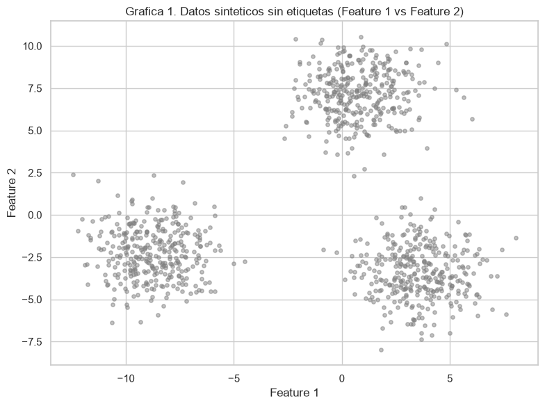

```python
fig, ax = plt.subplots(figsize=(8, 6))
ax.scatter(df['Feature 1'], df['Feature 2'], color='gray', alpha=0.5, s=15)
ax.set_xlabel('Feature 1')
ax.set_ylabel('Feature 2')
ax.set_title('Grafica 1. Datos sinteticos sin etiquetas (Feature 1 vs Feature 2)')
plt.tight_layout()
plt.show()
```

Aquí podemos ver que a simple vista sí se distinguen **3 nubes de puntos**: una arriba en el centro, una a la izquierda y una abajo a la derecha. Las de arriba y abajo a la derecha están más cerca entre sí y se tocan un poco en los bordes. Nosotros lo vemos fácil porque son solo 2 variables, pero el algoritmo no "ve" la gráfica: tiene que descubrir los grupos solo con las distancias entre puntos.

## 1.2 Asignación aleatoria inicial

El primer paso del algoritmo es asignar a cada observación un cluster al azar (0, 1 o 2). Se fija una semilla (`np.random.seed(42)`, la misma que usamos en clase) para que el resultado se pueda reproducir.

```python
np.random.seed(42)
df['Cluster'] = np.random.choice([0, 1, 2], size=len(df))

print("Observaciones en cada cluster aleatorio:")
print(df['Cluster'].value_counts().sort_index())
df.head()
```

```
Observaciones en cada cluster aleatorio:
Cluster
0    355
1    326
2    319
Name: count, dtype: int64
```

|  | Feature 1 | Feature 2 | Cluster |
| --- | --- | --- | --- |
| 0 | -0.864864 | -2.040380 | 2 |
| 1 | 2.340693 | 6.290997 | 0 |
| 2 | -10.054261 | -2.924473 | 2 |
| 3 | -10.789756 | -2.944428 | 2 |
| 4 | -9.613188 | -0.502041 | 0 |

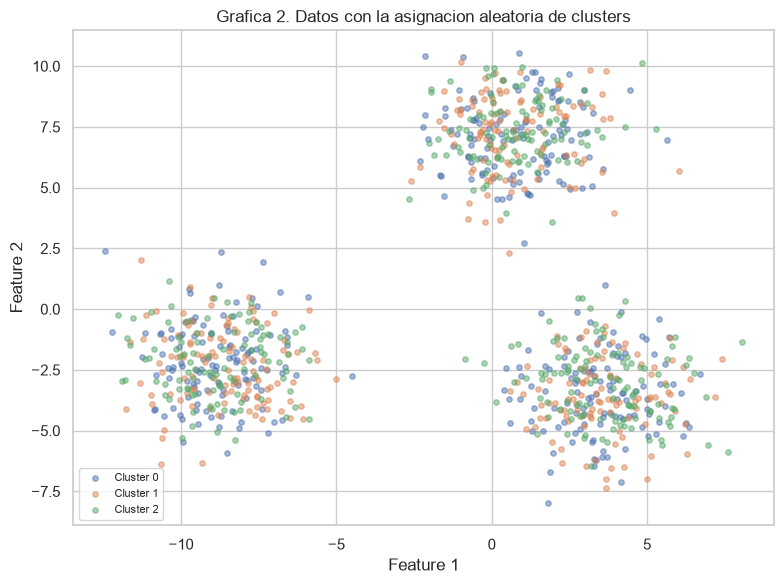

```python
#Codigo hecho con claude
def graficar_clusters(datos, titulo, centroides=None, ax=None):
    # Grafica los puntos coloreados por cluster y, si se dan, los centroides como una X negra
    if ax is None:
        fig, ax = plt.subplots(figsize=(8, 6))
    for k in sorted(datos['Cluster'].unique()):
        sub = datos[datos['Cluster'] == k]
        ax.scatter(sub['Feature 1'], sub['Feature 2'], color=colores[int(k)], alpha=0.5, s=15, label=f'Cluster {int(k)}')
    if centroides is not None:
        ax.scatter(centroides['Feature 1'], centroides['Feature 2'], color='black', marker='X',
                   s=250, edgecolors='white', linewidths=1.5, label='Centroides')
    ax.set_xlabel('Feature 1')
    ax.set_ylabel('Feature 2')
    ax.set_title(titulo)
    ax.legend(loc='lower left', fontsize=8)
    return ax

graficar_clusters(df, 'Grafica 2. Datos con la asignacion aleatoria de clusters')
plt.tight_layout()
plt.show()
```

Como la asignación es al azar, cada cluster quedó con más o menos la tercera parte de los datos (alrededor de 333 cada uno), y los colores están completamente **revueltos**: hay puntos de los 3 colores en las 3 nubes. Este es el punto de partida del algoritmo, y claramente todavía no tiene nada que ver con los grupos reales.

## 1.3 Centroides

El centroide de un cluster es el vector que tiene el **promedio de cada variable** de las observaciones de ese cluster. Como tenemos 2 variables, cada centroide es un punto en el plano. Se calcula agrupando por cluster y sacando la media con `groupby`.

```python
def calcular_centroides(datos):
    # Promedio de cada variable dentro de cada cluster
    return datos.groupby('Cluster')[['Feature 1', 'Feature 2']].mean()

centroides = calcular_centroides(df)
print("Centroides de los clusters aleatorios:")
print(centroides.round(3))
print("\nPromedio general de los datos:")
print(df[['Feature 1', 'Feature 2']].mean().round(3))
```

```
Centroides de los clusters aleatorios:
         Feature 1  Feature 2
Cluster
0           -1.586      0.614
1           -1.637      0.414
2           -1.175      0.545

Promedio general de los datos:
Feature 1   -1.472
Feature 2    0.527
dtype: float64
```

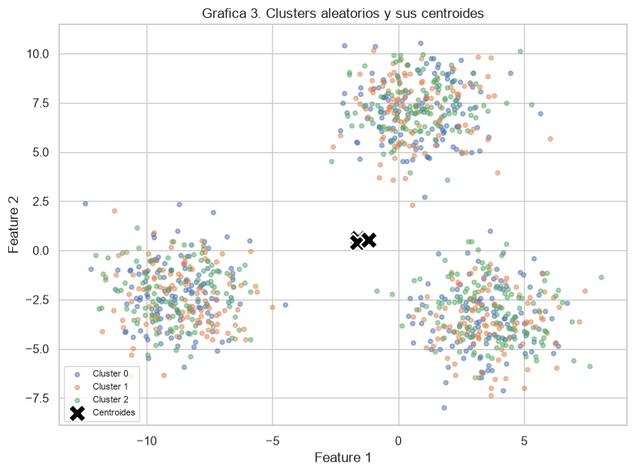

```python
graficar_clusters(df, 'Grafica 3. Clusters aleatorios y sus centroides', centroides)
plt.tight_layout()
plt.show()
```

Los 3 centroides quedaron prácticamente **encimados en el centro de los datos**, muy cerca del promedio general (-1.47, 0.53). Esto tiene sentido: como cada cluster aleatorio es una muestra al azar de todos los puntos, el promedio de cada uno se parece mucho al promedio de todos. Las pequeñas diferencias entre los 3 centroides son las que van a hacer que el algoritmo empiece a separar los grupos.

## 1.4 Actualización

Ahora viene la parte que se repite. En cada iteración:

1. Se calcula la **distancia euclideana al cuadrado** de cada observación a cada centroide, y cada observación se reasigna al cluster del centroide más cercano.
2. Se calculan los **nuevos centroides** con las nuevas etiquetas.

Para que este paso se pueda iterar, la función actualiza la columna `Cluster` del **mismo** DataFrame (no se crea uno nuevo en cada paso) y regresa los nuevos centroides y cuántas observaciones cambiaron de cluster. También se define una función para calcular el objetivo de K-means (la variación total dentro de los clusters), para ver si de verdad va bajando.

La distancia se calcula para todas las observaciones a la vez con `numpy` (restando cada centroide a todos los puntos), en vez de ir fila por fila como en clase con `apply`, porque es mucho más rápido y da exactamente lo mismo.

```python
#Codigo hecho con claude
def actualizar(datos, centroides):
    # 1) Distancia euclideana al cuadrado de cada punto a cada centroide (matriz de n x K)
    puntos = datos[['Feature 1', 'Feature 2']].values
    distancias = ((puntos[:, None, :] - centroides.values[None, :, :]) ** 2).sum(axis=2)
    # 2) Cada punto se va al cluster del centroide mas cercano
    nuevas = centroides.index.values[distancias.argmin(axis=1)]
    cambios = int((nuevas != datos['Cluster'].values).sum())
    datos['Cluster'] = nuevas                  # se actualiza el mismo DataFrame
    # 3) Nuevos centroides con las nuevas etiquetas
    return calcular_centroides(datos), cambios

def variacion_dentro(datos):
    # Objetivo de K-means: suma de distancias al cuadrado de cada punto al centroide de su cluster
    total = 0
    for k, grupo in datos.groupby('Cluster')[['Feature 1', 'Feature 2']]:
        total += ((grupo - grupo.mean()) ** 2).values.sum()
    return total

print(f"Variacion dentro de los clusters (asignacion aleatoria): {variacion_dentro(df):,.1f}")
centroides, cambios = actualizar(df, centroides)
print(f"Observaciones que cambiaron de cluster: {cambios}")
print(f"Variacion dentro de los clusters (despues de 1 actualizacion): {variacion_dentro(df):,.1f}")
print("\nNuevos centroides:")
print(centroides.round(3))
```

```
Variacion dentro de los clusters (asignacion aleatoria): 54,737.9
Observaciones que cambiaron de cluster: 661
Variacion dentro de los clusters (despues de 1 actualizacion): 20,452.3

Nuevos centroides:
         Feature 1  Feature 2
Cluster
0           -0.973      7.613
1           -8.723     -2.240
2            2.624      1.081
```

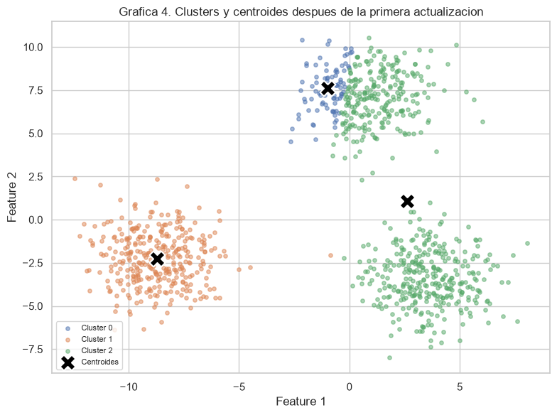

```python
graficar_clusters(df, 'Grafica 4. Clusters y centroides despues de la primera actualizacion', centroides)
plt.tight_layout()
plt.show()
```

Con **una sola actualización** el cambio es enorme: **661 observaciones** (dos terceras partes) cambiaron de cluster, y la variación dentro de los clusters bajó de 54,738 a 20,452. En la gráfica ya no hay colores revueltos: el plano quedó partido en 3 regiones, y cada centroide se movió hacia una de las nubes. Todavía no está perfecto (el cluster de abajo a la derecha se "come" parte de la nube de arriba), pero ya se parece mucho más a los grupos reales.

Ahora vamos a repetir la actualización **hasta que ninguna observación cambie de cluster**, que es la condición de paro del algoritmo. En cada iteración se guarda el objetivo, cuántas observaciones cambiaron y una copia de las etiquetas para poder graficar cómo fue avanzando.

```python
historial = [{'Iteracion': 1, 'Cambios': cambios, 'Variacion dentro': variacion_dentro(df)}]
fotos = {1: (df.copy(), centroides.copy())}

iteracion = 1
while cambios > 0 and iteracion < 50:
    iteracion += 1
    centroides, cambios = actualizar(df, centroides)
    historial.append({'Iteracion': iteracion, 'Cambios': cambios, 'Variacion dentro': variacion_dentro(df)})
    fotos[iteracion] = (df.copy(), centroides.copy())

historial = pd.DataFrame(historial).set_index('Iteracion')
print(historial.round(1))
print("\nCentroides finales:")
print(centroides.round(3))
```

```
           Cambios  Variacion dentro
Iteracion
1              661           20452.3
2              234            5341.3
3               16            4532.4
4                0            4532.4

Centroides finales:
         Feature 1  Feature 2
Cluster
0            0.772      7.198
1           -8.747     -2.240
2            3.553     -3.397
```

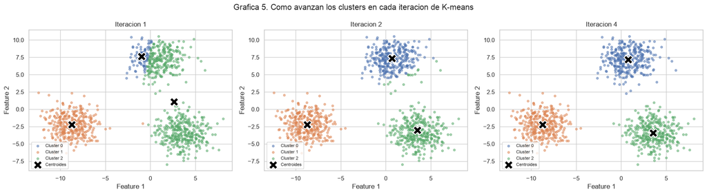

```python
#Codigo hecho con claude
fig, axes = plt.subplots(1, 3, figsize=(18, 5))
for ax, it in zip(axes, [1, 2, iteracion]):
    datos_it, cent_it = fotos[it]
    graficar_clusters(datos_it, f'Iteracion {it}', cent_it, ax=ax)
plt.suptitle('Grafica 5. Como avanzan los clusters en cada iteracion de K-means')
plt.tight_layout()
plt.show()
```

El algoritmo **convergió en 4 iteraciones**: en la cuarta ya ninguna observación cambió de cluster.

- En la tabla se ve que en cada iteración cambian cada vez menos observaciones (661, 234, 16 y 0), y que la variación dentro de los clusters baja muy rápido (de 20,452 a 5,341 y luego a 4,532) y después ya no cambia. Nunca sube, que es justo la propiedad del algoritmo que garantiza que siempre termina.
- En la Gráfica 5 se ve que en la iteración 2 el cluster de abajo a la derecha suelta los puntos de la nube de arriba, y al final los 3 clusters coinciden con las 3 nubes que veíamos a simple vista.
- Los centroides finales, (0.77, 7.20), (-8.75, -2.24) y (3.55, -3.40), quedaron en el centro de cada nube.

## 1.5 Estocasticidad

Ahora vamos a regresar al punto donde se asignaron los clusters de forma aleatoria, **quitar la semilla** y volver a correr todo el proceso. Para no repetir todo el código, se junta todo el algoritmo en una función que recibe el número de clusters y, opcionalmente, una semilla. Si no se le da semilla, cada vez que se corre sale una asignación inicial distinta.

```python
#Codigo hecho con claude
def kmeans_desde_cero(datos, k=3, semilla=None, max_iter=50):
    datos = datos[['Feature 1', 'Feature 2']].copy()
    if semilla is not None:
        np.random.seed(semilla)
    datos['Cluster'] = np.random.choice(range(k), size=len(datos))   # asignacion aleatoria
    centroides = calcular_centroides(datos)
    cambios, iteraciones = 1, 0
    while cambios > 0 and iteraciones < max_iter:
        iteraciones += 1
        centroides, cambios = actualizar(datos, centroides)
    return datos, centroides, iteraciones, variacion_dentro(datos)

datos_sin, cent_sin, it_sin, obj_sin = kmeans_desde_cero(df)   # sin semilla
print(f"Iteraciones: {it_sin}")
print(f"Variacion dentro de los clusters: {obj_sin:,.1f}")
print(f"Clusters que sobrevivieron: {datos_sin['Cluster'].nunique()}")
print("\nCentroides finales:")
print(cent_sin.round(3))
```

```
Iteraciones: 4
Variacion dentro de los clusters: 4,532.4
Clusters que sobrevivieron: 3

Centroides finales:
         Feature 1  Feature 2
Cluster
0            0.772      7.198
1            3.553     -3.397
2           -8.747     -2.240
```

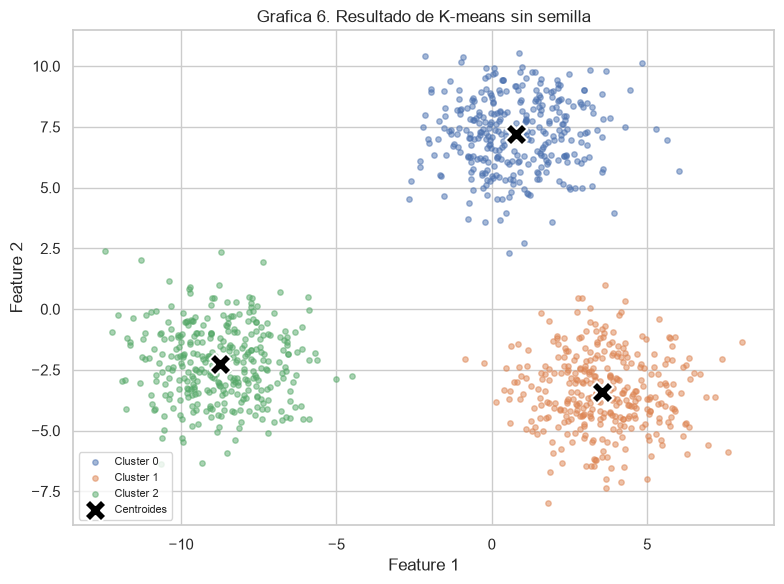

```python
graficar_clusters(datos_sin, 'Grafica 6. Resultado de K-means sin semilla', cent_sin)
plt.tight_layout()
plt.show()
```

Como esta corrida no tiene semilla, cada vez que se vuelve a correr la celda sale una asignación inicial distinta, así que el número de iteraciones y el orden de los colores pueden cambiar. Lo más probable es que llegue al mismo resultado de antes (variación dentro de 4,532 y los mismos 3 centroides), aunque con los **números de los clusters cambiados**: lo que antes era el cluster 0 ahora puede ser el 2. Eso no es un problema, porque los números de los clusters son solo nombres.

Por último, igual que en clase, se corre el algoritmo con otra semilla fija (123) para tener otro punto de partida que sí se pueda reproducir.

```
Iteraciones: 3
Variacion dentro de los clusters: 4,532.4

Centroides finales:
         Feature 1  Feature 2
Cluster
0            0.772      7.198
1            3.553     -3.397
2           -8.747     -2.240
```

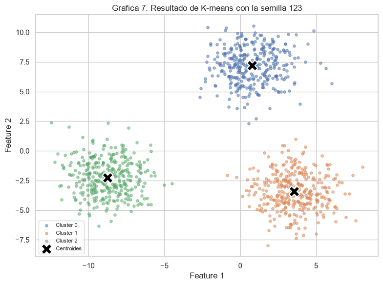

```python
datos_123, cent_123, it_123, obj_123 = kmeans_desde_cero(df, semilla=123)
print(f"Iteraciones: {it_123}")
print(f"Variacion dentro de los clusters: {obj_123:,.1f}")
print("\nCentroides finales:")
print(cent_123.round(3))

graficar_clusters(datos_123, 'Grafica 7. Resultado de K-means con la semilla 123', cent_123)
plt.tight_layout()
plt.show()
```

Con la semilla 123 el algoritmo convergió en **3 iteraciones** (una menos que con la semilla 42) y llegó **a la misma solución**: los mismos 3 centroides y la misma variación dentro (4,532), solo con los números de los clusters en otro orden. En este dataset los 3 grupos están tan separados que distintos puntos de partida llegan al mismo lugar.

Pero eso no siempre pasa. Como el algoritmo solo garantiza un **óptimo local**, con otra asignación inicial puede quedarse en una solución peor (por ejemplo, si un cluster se queda sin observaciones en una de las primeras iteraciones y desaparece). Por eso en la práctica se corre muchas veces desde asignaciones distintas y se queda la solución con la menor variación dentro, que es lo que hace el parámetro `n_init` de `KMeans` en scikit-learn, que se usa en la siguiente parte.

# Parte 2. K-means con datos reales: NCI60

Ahora se aplica K-means a un problema real. **NCI60** es un dataset del Instituto Nacional del Cáncer de Estados Unidos que viene en la librería `ISLP` (la del libro *An Introduction to Statistical Learning*). Tiene la **expresión de 6,830 genes** medida con microarreglos en **64 líneas celulares de cáncer**, y para cada una se sabe de qué tipo de cáncer es.

La pregunta es: si agrupamos las líneas celulares **solo por su expresión genética**, sin decirle al algoritmo el tipo de cáncer, ¿los grupos que salen se parecen a los tipos de cáncer? Las etiquetas del tipo de cáncer no se usan para entrenar nada, solo para interpretar los clusters al final.

## 2.1 Importar el dataset y revisar sus características

Primero se instala `ISLP` (si no está instalada) y se carga NCI60 con `load_data('NCI60')`, que regresa un diccionario con la matriz de expresión (`data`) y el tipo de cáncer (`labels`).

```python
try:
    from ISLP import load_data
except ImportError:
    %pip install -q ISLP
    from ISLP import load_data

nci60 = load_data('NCI60')
datos_gen = nci60['data']                 # expresion de cada gen (filas = lineas celulares)
tipos = nci60['labels']['label'].values   # tipo de cancer de cada linea celular

print("Shape de los datos:", datos_gen.shape)
print("Shape de las etiquetas:", nci60['labels'].shape)
print()
print(pd.DataFrame(datos_gen[:, :8], columns=[f'Gen {j}' for j in range(8)]).head())
```

```
Shape de los datos: (64, 6830)
Shape de las etiquetas: (64, 1)

      Gen 0     Gen 1     Gen 2     Gen 3     Gen 4         Gen 5     Gen 6  \
0  0.300000  1.180000  0.550000  1.140000 -0.265000 -7.000000e-02  0.350000
1  0.679961  1.289961  0.169961  0.379961  0.464961  5.799610e-01  0.699961
2  0.940000 -0.040000 -0.170000 -0.040000 -0.605000  0.000000e+00  0.090000
3  0.280000 -0.310000  0.680000 -0.810000  0.625000 -1.387779e-17  0.170000
4  0.485000 -0.465000  0.395000  0.905000  0.200000 -5.000000e-03  0.085000

      Gen 7
0 -0.315000
1  0.724961
2  0.645000
3  0.245000
4  0.110000
```

```python
conteo_tipos = pd.Series(tipos).value_counts()
print("Count de labels (tipo de cancer):")
print(conteo_tipos)
```

```
Count de labels (tipo de cancer):
RENAL          9
NSCLC          9
MELANOMA       8
BREAST         7
COLON          7
OVARIAN        6
LEUKEMIA       6
CNS            5
PROSTATE       2
UNKNOWN        1
K562B-repro    1
K562A-repro    1
MCF7A-repro    1
MCF7D-repro    1
Name: count, dtype: int64
```

El dataset tiene **64 observaciones y 6,830 variables**, o sea, muchísimas más variables que observaciones ($p \gg n$). Hay que tener en cuenta varias cosas:

- Hay **14 etiquetas**, pero 4 de ellas (`K562A-repro`, `K562B-repro`, `MCF7A-repro` y `MCF7D-repro`) son **réplicas** de líneas celulares que ya están en el dataset: K562 es una línea de leucemia y MCF7 una de cáncer de mama. También hay una `UNKNOWN` (tipo desconocido). Así que en realidad son 9 tipos de cáncer, y algunos con muy pocas observaciones (próstata solo tiene 2).
- Los grupos más grandes son renal y pulmón (NSCLC, 9 cada uno) y melanoma (8).

Con tan pocas observaciones por tipo y tantos genes, no hay que esperar que los clusters coincidan perfectamente con los tipos de cáncer, pero sí que los tipos con perfiles genéticos muy marcados queden juntos.

## 2.2 K-means con scikit-learn sobre los datos originales

Se usa `KMeans` de scikit-learn con los siguientes parámetros:

- `n_clusters=4`: dentro del rango de 3 a 5 que pide el taller (más adelante se revisa si 4 tiene sentido).
- `n_init=20`: el algoritmo se corre 20 veces desde inicializaciones distintas y se queda la de menor variación dentro (lo que vimos en la Parte 1.5). Está dentro del rango de 10 a 50.
- `random_state=67`: para que los resultados sean reproducibles.

En este primer intento se usan los **6,830 genes tal cual vienen**.

```python
from sklearn.cluster import KMeans

km_genes = KMeans(n_clusters=4, n_init=20, random_state=67)
cluster_genes = km_genes.fit_predict(datos_gen)

print("Observaciones por cluster:", np.bincount(cluster_genes))
print(f"Variacion dentro de los clusters (inertia): {km_genes.inertia_:,.0f}")
```

```
Observaciones por cluster: [35 12  9  8]
Variacion dentro de los clusters (inertia): 200,524
```

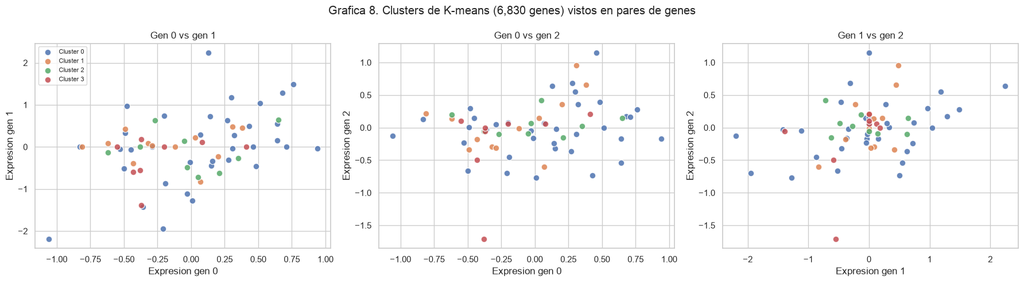

```python
#Codigo hecho con claude
pares = [(0, 1), (0, 2), (1, 2)]
fig, axes = plt.subplots(1, 3, figsize=(18, 5))
for ax, (a, b) in zip(axes, pares):
    for k in range(4):
        m = cluster_genes == k
        ax.scatter(datos_gen[m, a], datos_gen[m, b], color=colores[k], s=60, alpha=0.85,
                   edgecolors='white', label=f'Cluster {k}')
    ax.set_xlabel(f'Expresion gen {a}')
    ax.set_ylabel(f'Expresion gen {b}')
    ax.set_title(f'Gen {a} vs gen {b}')
axes[0].legend(fontsize=8)
plt.suptitle('Grafica 8. Clusters de K-means (6,830 genes) vistos en pares de genes')
plt.tight_layout()
plt.show()
```

Aquí podemos ver que en cualquier par de genes los 4 clusters están **completamente revueltos**: no se ve ninguna separación entre colores. Esto no quiere decir que K-means haya hecho algo mal, sino que los clusters se formaron con las distancias en **6,830 dimensiones**, y al ver solo 2 genes de 6,830 estamos viendo una parte mínima de la información. Graficar genes sueltos no sirve para entender los clusters, y además, con tantas variables, las distancias se llenan del ruido de miles de genes que no tienen que ver con el tipo de cáncer. Por eso el siguiente paso es usar PCA.

## 2.3 Preprocesamiento con PCA

Antes de PCA se **estandarizan** los genes (media 0 y desviación estándar 1 para cada gen) con `StandardScaler`, porque PCA busca las direcciones de mayor varianza, y si un gen tiene una escala más grande que los demás dominaría los primeros componentes solo por su escala. Después se ajusta PCA con todos los componentes posibles (64, porque hay 64 observaciones) para poder ver cuánta varianza explica cada uno.

```python
from sklearn.preprocessing import StandardScaler
from sklearn.decomposition import PCA

datos_esc = StandardScaler().fit_transform(datos_gen)
pca = PCA()
componentes = pca.fit_transform(datos_esc)

df_pca = pd.DataFrame(componentes, columns=[f'PC{i+1}' for i in range(componentes.shape[1])])
df_pca['Tipo'] = tipos
print("Shape de los componentes:", componentes.shape)
df_pca[['PC1', 'PC2', 'PC3', 'Tipo']].head()
```

```
Shape de los componentes: (64, 64)
```

|  | PC1 | PC2 | PC3 | Tipo |
| --- | --- | --- | --- | --- |
| 0 | 19.838042 | -3.555636 | -9.812399 | CNS |
| 1 | 23.089215 | -6.441460 | -13.478251 | CNS |
| 2 | 27.456114 | -2.465143 | -3.533054 | CNS |
| 3 | 42.816801 | 9.768358 | -0.890073 | RENAL |
| 4 | 55.418530 | 5.198897 | -21.094558 | BREAST |

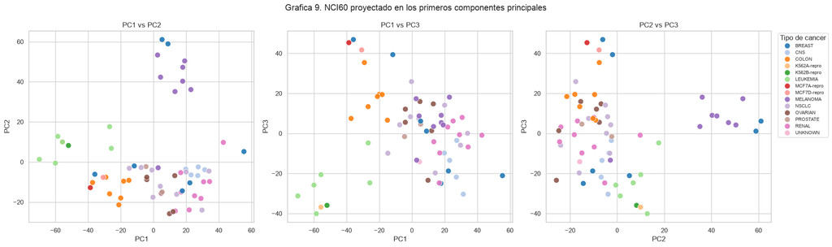

```python
#Codigo hecho con claude
tipos_orden = sorted(set(tipos))
paleta_tipos = dict(zip(tipos_orden, sns.color_palette('tab20', len(tipos_orden))))

fig, axes = plt.subplots(1, 3, figsize=(20, 6))
for ax, (a, b) in zip(axes, [('PC1', 'PC2'), ('PC1', 'PC3'), ('PC2', 'PC3')]):
    sns.scatterplot(data=df_pca, x=a, y=b, hue='Tipo', hue_order=tipos_orden, palette=paleta_tipos,
                    s=90, alpha=0.9, edgecolor='white', ax=ax, legend=(a, b) == ('PC2', 'PC3'))
    ax.set_title(f'{a} vs {b}')
axes[2].legend(bbox_to_anchor=(1.02, 1), loc='upper left', title='Tipo de cancer', fontsize=8)
plt.suptitle('Grafica 9. NCI60 proyectado en los primeros componentes principales')
plt.tight_layout()
plt.show()
```

Ya con solo 2 componentes se ve mucha más estructura que con cualquier par de genes:

- En **PC1 vs PC2** los **melanomas** quedan todos juntos arriba (PC2 alto), las **leucemias** (con sus réplicas K562) a la izquierda, y los de **colon** forman un grupito abajo a la izquierda del centro. Todo lo demás queda amontonado abajo a la derecha.
- En **PC1 vs PC3** las leucemias quedan abajo a la izquierda, y los de colon con las réplicas de MCF7 se van hacia arriba. En **PC2 vs PC3** los melanomas se separan a la derecha.
- Otros tipos, como mama (BREAST) y pulmón (NSCLC), quedan **repartidos** por todo el plano: no tienen un perfil genético tan homogéneo. Un detalle curioso es que siempre hay 2 líneas "de mama" junto a los melanomas. En la literatura se ha reportado que dos líneas de mama de NCI60 (MDA-MB-435 y MDA-N) en realidad parecen ser de origen melanoma, lo que explicaría por qué siempre se agrupan con ellos.

Para determinar la cantidad de clusters, en estas gráficas se alcanzan a distinguir unos **3 o 4 grupos principales** (leucemia, melanoma, colon y "todo lo demás"), pero no hay una separación tan clara como en el dataset sintético. Antes de decidir, hay que ver cuántos componentes conviene usar.

### Varianza explicada

Se grafica la proporción de varianza explicada por cada componente (PVE) y la acumulada, en dos gráficas separadas porque tienen escalas muy distintas.

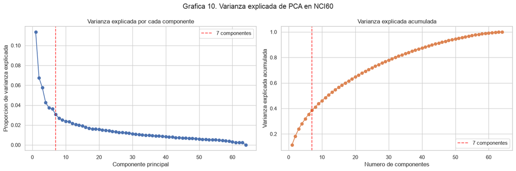

```
         PVE  PVE acumulada
PC1   0.1136         0.1136
PC2   0.0676         0.1812
PC3   0.0575         0.2387
PC4   0.0425         0.2811
PC5   0.0373         0.3185
PC6   0.0362         0.3547
PC7   0.0307         0.3853
PC8   0.0269         0.4122
PC9   0.0253         0.4375
PC10  0.0238         0.4613
Componentes para explicar el 50% de la varianza: 12
Componentes para explicar el 70% de la varianza: 24
Componentes para explicar el 90% de la varianza: 44
```

```python
#Codigo hecho con claude
pve = pca.explained_variance_ratio_
pve_acum = np.cumsum(pve)

fig, axes = plt.subplots(1, 2, figsize=(15, 5))
axes[0].plot(range(1, len(pve) + 1), pve, marker='o', color='#4C72B0')
axes[0].axvline(7, color='red', linestyle='--', alpha=0.7, label='7 componentes')
axes[0].set_xlabel('Componente principal')
axes[0].set_ylabel('Proporcion de varianza explicada')
axes[0].set_title('Varianza explicada por cada componente')
axes[0].legend()
axes[1].plot(range(1, len(pve) + 1), pve_acum, marker='o', color='#DD8452')
axes[1].axvline(7, color='red', linestyle='--', alpha=0.7, label='7 componentes')
axes[1].set_xlabel('Numero de componentes')
axes[1].set_ylabel('Varianza explicada acumulada')
axes[1].set_title('Varianza explicada acumulada')
axes[1].legend()
plt.suptitle('Grafica 10. Varianza explicada de PCA en NCI60')
plt.tight_layout()
plt.show()

print(pd.DataFrame({'PVE': pve[:10], 'PVE acumulada': pve_acum[:10]}, index=[f'PC{i+1}' for i in range(10)]).round(4))
for umbral in [0.5, 0.7, 0.9]:
    print(f"Componentes para explicar el {umbral:.0%} de la varianza: {np.argmax(pve_acum >= umbral) + 1}")
```

Se van a usar los **primeros 7 componentes** (38.5% de la varianza). Puede parecer poco, pero la idea del preprocesamiento es quedarse con las direcciones donde está la estructura principal y tirar el ruido: después del codo, cada componente es casi igual de "importante" que el siguiente, que es lo que se espera del ruido. Con 64 observaciones, meter 24 componentes es casi como volver a meter muchas variables con ruido.

### Determinar la cantidad de clusters

Se prueban de 2 a 8 clusters y para cada uno se calculan dos medidas:

- **Variación dentro (inertia):** siempre baja al aumentar $K$ (con más grupos, cada uno queda más compacto), así que no se elige el mínimo sino el punto donde deja de bajar tanto (**método del codo**).
- **Coeficiente de silueta:** para cada observación compara qué tan cerca está de su propio cluster contra el cluster vecino más cercano. Va de -1 a 1: cerca de 1 significa clusters bien separados, cerca de 0 significa que las observaciones están en la frontera entre clusters.

Se calcula con los 7 componentes seleccionados.

```
      Inertia  Silueta
K
2  131120.343    0.264
3  105387.265    0.287
4   85301.960    0.318
5   71182.622    0.305
6   58471.933    0.320
7   48274.816    0.346
8   39323.429    0.366
```

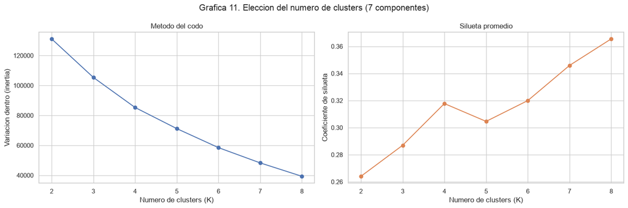

```python
#Codigo hecho con claude
from sklearn.metrics import silhouette_score

resultados_k = []
Z = componentes[:, :7]
for k in range(2, 9):
    km = KMeans(n_clusters=k, n_init=20, random_state=67).fit(Z)
    resultados_k.append({'K': k, 'Inertia': km.inertia_, 'Silueta': silhouette_score(Z, km.labels_)})
resultados_k = pd.DataFrame(resultados_k).set_index('K')
print(resultados_k.round(3))

fig, axes = plt.subplots(1, 2, figsize=(15, 5))
axes[0].plot(resultados_k.index, resultados_k['Inertia'], marker='o', color='#4C72B0')
axes[0].set_xlabel('Numero de clusters (K)')
axes[0].set_ylabel('Variacion dentro (inertia)')
axes[0].set_title('Metodo del codo')
axes[1].plot(resultados_k.index, resultados_k['Silueta'], marker='o', color='#DD8452')
axes[1].set_xlabel('Numero de clusters (K)')
axes[1].set_ylabel('Coeficiente de silueta')
axes[1].set_title('Silueta promedio')
plt.suptitle('Grafica 11. Eleccion del numero de clusters (7 componentes)')
plt.tight_layout()
plt.show()
```

- **Método del codo:** la variación dentro baja de forma casi constante de $K=2$ a $K=8$, sin un codo claro. Esto ya dice algo importante: los datos **no tienen grupos tan bien separados** como el dataset sintético.
- **Silueta:** con 7 componentes los valores están entre 0.26 y 0.37, con un máximo local en **$K=4$ (0.318)** dentro del rango de 3 a 5, y después vuelve a subir poco a poco con más clusters (que ya son grupos de 2 a 4 líneas celulares). Son valores moderados: sí hay estructura, pero las fronteras entre grupos no son muy marcadas.

Entonces se elige **$K=4$ con 7 componentes**: está dentro del rango del taller, es el mejor valor de silueta en ese rango, y coincide con los 4 grupos que se veían en la Gráfica 9. Pero hay que tener claro que no hay un número "correcto" de clusters; es una decisión que se toma con evidencia, y más adelante el clustering jerárquico ayuda a revisarla.

## 2.4 K-means con los componentes seleccionados

Se corre `KMeans` con los mismos parámetros que antes (`n_clusters=4`, `n_init=20`), pero ahora sobre los 7 componentes principales.

```python
km_pca = KMeans(n_clusters=4, n_init=20, random_state=67)
cluster_pca = km_pca.fit_predict(componentes[:, :7])
df_pca['Cluster'] = cluster_pca

print("Observaciones por cluster:", np.bincount(cluster_pca))
print(f"Silueta: {silhouette_score(componentes[:, :7], cluster_pca):.3f}")
```

```
Observaciones por cluster: [35  9 12  8]
Silueta: 0.318
```

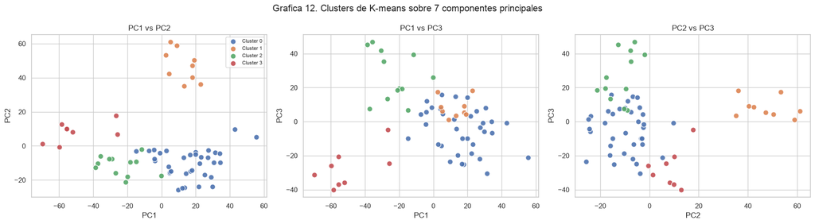

```python
#Codigo hecho con claude
fig, axes = plt.subplots(1, 3, figsize=(18, 5))
for ax, (a, b) in zip(axes, [('PC1', 'PC2'), ('PC1', 'PC3'), ('PC2', 'PC3')]):
    for k in range(4):
        sub = df_pca[df_pca['Cluster'] == k]
        ax.scatter(sub[a], sub[b], color=colores[k], s=70, alpha=0.9, edgecolors='white', label=f'Cluster {k}')
    ax.set_xlabel(a)
    ax.set_ylabel(b)
    ax.set_title(f'{a} vs {b}')
axes[0].legend(fontsize=8)
plt.suptitle('Grafica 12. Clusters de K-means sobre 7 componentes principales')
plt.tight_layout()
plt.show()
```

Ahora sí se ven los clusters en las gráficas, a diferencia de la Gráfica 8:

- En **PC1 vs PC2** el cluster 1 queda arriba (donde estaban los melanomas), el cluster 3 a la izquierda (donde estaban las leucemias) y el cluster 0, el más grande, abajo a la derecha.
- El cluster 2 queda pegado al cluster 0 en PC1 vs PC2, pero en **PC1 vs PC3** se separa claramente hacia arriba. Por eso es importante ver varios pares de componentes: cada uno muestra una parte distinta de la estructura, y K-means está usando los 7 a la vez.

Hay un grupo grande de 35 líneas celulares y tres grupos más chicos (9, 12 y 8). Para saber qué significa cada uno hay que compararlos con el tipo de cáncer.

## 2.5 Interpretación: tipo de cáncer contra cluster

Se hace una tabla cruzada con la cantidad de líneas celulares de cada tipo de cáncer en cada cluster. Recordemos que K-means nunca vio el tipo de cáncer.

```python
tabla_km = pd.crosstab(df_pca['Tipo'], df_pca['Cluster'], margins=True, margins_name='Total')
tabla_km.columns.name = 'Cluster'
print(tabla_km)
```

```
Cluster       0  1   2  3  Total
Tipo
BREAST        3  2   2  0      7
CNS           5  0   0  0      5
COLON         0  0   7  0      7
K562A-repro   0  0   0  1      1
K562B-repro   0  0   0  1      1
LEUKEMIA      0  0   0  6      6
MCF7A-repro   0  0   1  0      1
MCF7D-repro   0  0   1  0      1
MELANOMA      1  7   0  0      8
NSCLC         8  0   1  0      9
OVARIAN       6  0   0  0      6
PROSTATE      2  0   0  0      2
RENAL         9  0   0  0      9
UNKNOWN       1  0   0  0      1
Total        35  9  12  8     64
```

Esta tabla es la que le da sentido a los clusters:

- **Cluster 3 (8 líneas):** las **6 leucemias** y las 2 réplicas de K562 (que también es leucemia). Es un cluster **puro**: todas las leucemias y nada más. La leucemia es un cáncer de la sangre, muy distinto de los tumores sólidos, así que tiene sentido que su perfil genético sea el más diferente.
- **Cluster 1 (9 líneas):** 7 de los 8 **melanomas** y 2 de mama. Casi todo melanoma.
- **Cluster 2 (12 líneas):** los **7 de colon**, las 2 réplicas de MCF7 (mama), 2 de mama y 1 de pulmón.
- **Cluster 0 (35 líneas):** el grupo grande con todo lo demás: los 9 renales, los 5 del sistema nervioso, los 6 de ovario, 8 de los 9 de pulmón y los de próstata.

Es decir, **K-means encontró por sí solo los tipos de cáncer con perfiles genéticos más marcados** (leucemia, melanoma y colon), y juntó en un solo grupo los tipos que se parecen más entre sí. Algo interesante es que **mama** quedó repartida en 3 clusters distintos (3, 2 y 2 líneas): el cáncer de mama no es un solo tipo homogéneo a nivel genético, y las 2 que quedaron con los melanomas son las que ya se veían junto a ellos en la Gráfica 9.

## 2.6 Genes más relevantes (heatmap)

Por último se busca **qué genes son los que más separan a los clusters**. Para que sea más fácil de leer, se usan solo 2 clusters:

1. Se corre K-means con 2 clusters sobre los 7 componentes.
2. Se calcula la expresión promedio de cada uno de los 6,830 genes en cada cluster (con los datos originales).
3. Se calcula la diferencia absoluta entre los dos promedios para cada gen.
4. Se seleccionan los **40 genes** con mayor diferencia (dentro del rango de 30 a 50).
5. Se estandarizan esos 40 genes (cada gen con media 0 y desviación estándar 1) para que todos se vean en la misma escala de color.
6. Se ordenan las líneas celulares por cluster y se grafica el heatmap.

```python
km_2 = KMeans(n_clusters=2, n_init=20, random_state=67)
cluster_2 = km_2.fit_predict(componentes[:, :7])

expresion = pd.DataFrame(datos_gen, columns=[f'Gen {j}' for j in range(datos_gen.shape[1])])
promedio_cluster = expresion.groupby(cluster_2).mean()                 # 2 x 6830
diferencia = (promedio_cluster.loc[0] - promedio_cluster.loc[1]).abs()
genes_top = diferencia.nlargest(40).index

top_esc = pd.DataFrame(StandardScaler().fit_transform(expresion[genes_top]), columns=genes_top)
top_esc['Cluster'] = cluster_2
top_esc['Tipo'] = tipos
top_esc = top_esc.sort_values('Cluster')
```

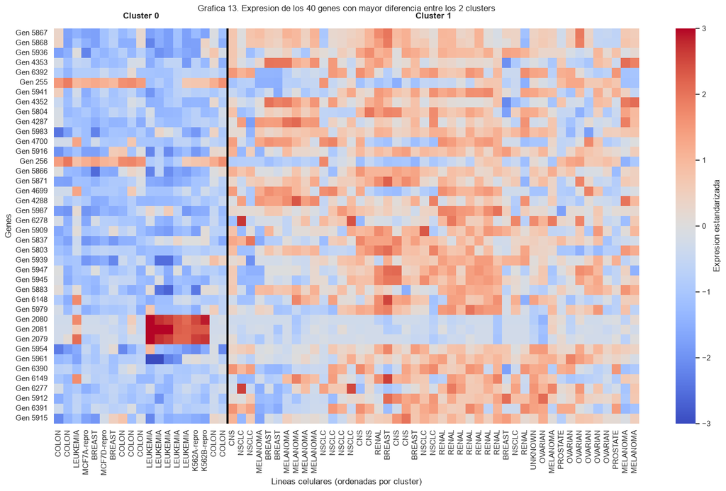

```python
#Codigo hecho con claude
fig, ax = plt.subplots(figsize=(16, 10))
sns.heatmap(top_esc[genes_top].T, cmap='coolwarm', center=0, vmin=-3, vmax=3,
            xticklabels=top_esc['Tipo'], cbar_kws={'label': 'Expresion estandarizada'}, ax=ax)
corte = (top_esc['Cluster'] == 0).sum()
ax.axvline(corte, color='black', linewidth=3)
ax.text(corte / 2, -1, 'Cluster 0', ha='center', fontsize=12, fontweight='bold')
ax.text(corte + (len(top_esc) - corte) / 2, -1, 'Cluster 1', ha='center', fontsize=12, fontweight='bold')
ax.set_xlabel('Lineas celulares (ordenadas por cluster)')
ax.set_ylabel('Genes')
ax.set_title('Grafica 13. Expresion de los 40 genes con mayor diferencia entre los 2 clusters', pad=25)
plt.tight_layout()
plt.show()
```

Con 2 clusters, K-means separa a las leucemias (con sus réplicas K562), los de colon, las réplicas de MCF7 y algunas de mama (cluster 0, a la izquierda de la línea negra) del resto de las líneas celulares (cluster 1: melanomas, renales, pulmón, ovario, sistema nervioso y próstata). En el heatmap cada fila es un gen y cada columna una línea celular; rojo es expresión arriba del promedio de ese gen y azul es abajo:

- La mayoría de los 40 genes están **más bajos (azul) en el cluster 0 y más altos (rojo) en el cluster 1**.
- Hay unos cuantos genes al revés, como el 255 y el 256, que están más altos en el cluster 0.
- Los genes 2079, 2080 y 2081 son muy particulares: están altísimos (rojo oscuro) **solo en las leucemias** y sus réplicas, y normales en todo lo demás. Son genes que identifican a la leucemia dentro del cluster 0.
- Dentro del cluster 1 los colores no son tan parejos: por ejemplo, los melanomas tienen expresión más alta en los genes 4287, 4288, 4352 y 4353. Esto confirma que ese cluster junta tipos de cáncer distintos.

Esto es lo que hace útil al clustering en un problema real: no solo dice qué líneas celulares se parecen, sino que permite buscar **qué genes las hacen parecerse**, que es justo la información que le interesa a un biólogo.

# Parte 3. Clustering jerárquico con NCI60

En la Parte 2 tuvimos que elegir $K=4$ antes de correr K-means, y vimos que no había un número de clusters claramente mejor. El clustering jerárquico resuelve justo eso: no hay que elegir $K$ de antemano, porque el dendrograma muestra todos los agrupamientos posibles a la vez.

## 3.1 Dataset

Se usa el mismo dataset NCI60 de la librería `ISLP`. Se vuelve a cargar para que esta parte se pueda correr por separado.

```python
nci60 = load_data('NCI60')
datos_gen = nci60['data']
tipos = nci60['labels']['label'].values
print("Shape:", datos_gen.shape)
```

```
Shape: (64, 6830)
```

## 3.2 Preprocesamiento con PCA

El preprocesamiento es el mismo de la Parte 2: se estandarizan los genes y se aplica PCA. Primero se vuelve a graficar la varianza explicada para determinar cuántos componentes principales usar, y después se grafica **PC1 vs PC2** coloreado por tipo de cáncer, para responder la pregunta del taller: **¿estamos seguros de que seleccionamos el número correcto de clusters?**

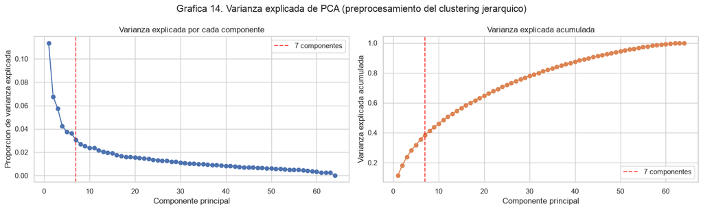

```
Varianza explicada por los primeros 7 componentes: 38.5%
```

```python
#Codigo hecho con claude
datos_esc = StandardScaler().fit_transform(datos_gen)
pca = PCA()
componentes = pca.fit_transform(datos_esc)
pve = pca.explained_variance_ratio_

fig, axes = plt.subplots(1, 2, figsize=(15, 4.5))
axes[0].plot(range(1, len(pve) + 1), pve, marker='o', color='#4C72B0')
axes[1].plot(range(1, len(pve) + 1), np.cumsum(pve), marker='o', color='#DD8452')
for ax, nombre in zip(axes, ['Varianza explicada por cada componente', 'Varianza explicada acumulada']):
    ax.axvline(7, color='red', linestyle='--', alpha=0.7, label='7 componentes')
    ax.set_xlabel('Componente principal')
    ax.set_title(nombre)
    ax.legend()
axes[0].set_ylabel('Proporcion de varianza explicada')
axes[1].set_ylabel('Varianza explicada acumulada')
plt.suptitle('Grafica 14. Varianza explicada de PCA (preprocesamiento del clustering jerarquico)')
plt.tight_layout()
plt.show()
print(f"Varianza explicada por los primeros 7 componentes: {np.cumsum(pve)[6]:.1%}")
```

Es la misma gráfica de la Parte 2, porque son los mismos datos con el mismo preprocesamiento: hay un codo alrededor del componente 7, y los primeros 7 componentes explican el 38.5% de la varianza. Con eso se queda determinada la cantidad de componentes principales, que se usan para visualizar los datos y como referencia para el número de clusters.

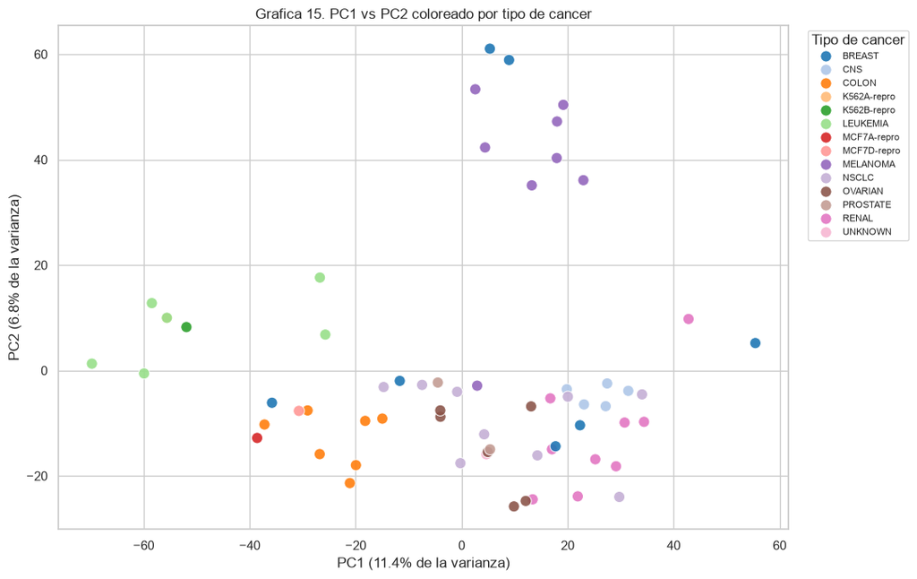

```python
#Codigo hecho con claude
fig, ax = plt.subplots(figsize=(11, 7))
sns.scatterplot(x=componentes[:, 0], y=componentes[:, 1], hue=tipos, hue_order=tipos_orden, palette=paleta_tipos,
                s=90, alpha=0.9, edgecolor='white', ax=ax)
ax.legend(bbox_to_anchor=(1.02, 1), loc='upper left', title='Tipo de cancer', fontsize=8)
ax.set_xlabel(f'PC1 ({pve[0]:.1%} de la varianza)')
ax.set_ylabel(f'PC2 ({pve[1]:.1%} de la varianza)')
ax.set_title('Grafica 15. PC1 vs PC2 coloreado por tipo de cancer')
plt.tight_layout()
plt.show()
```

La respuesta honesta es que **no**. Hay 9 tipos de cáncer reales (14 etiquetas contando réplicas y el desconocido), y en PC1 vs PC2 solo algunos forman grupos claros (leucemia, melanoma y colon), mientras que los demás se enciman. En la Parte 2 tampoco hubo un codo claro y la silueta siguió subiendo con más clusters. Con K-means el número de clusters es una decisión que hay que tomar antes, y si nos equivocamos, el algoritmo igual va a regresar exactamente esa cantidad de grupos. El dendrograma del clustering jerárquico permite ver cómo se van formando los grupos para cualquier número de clusters y decidir después.

## 3.3 Clustering jerárquico: método complete y métrica euclideana

Se usa la función `linkage` de `scipy` con el método `'complete'` y la métrica `'euclidean'`, y se grafica el dendrograma en un solo color (monocromático). En cada hoja se pone el tipo de cáncer de la línea celular, para poder interpretar el árbol.

El clustering se hace sobre los **6,830 genes estandarizados** (igual que en el laboratorio del libro *ISLP*), para que las disimilitudes usen toda la información y para que la métrica de correlación de más adelante tenga sentido (la correlación entre dos líneas celulares se calcula a lo largo de sus 6,830 genes; con solo 7 componentes serían 7 números por línea celular). PCA se usó para visualizar los datos y para tener una idea de cuántos clusters hay.

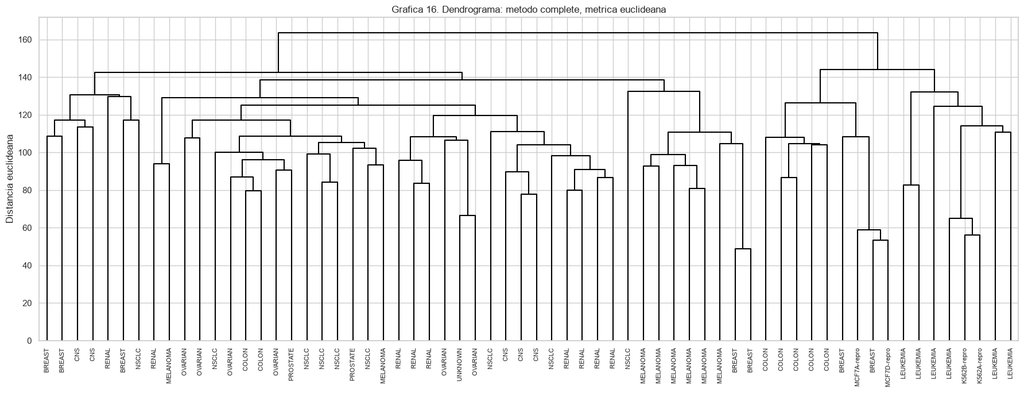

```
Alturas de las ultimas 5 uniones: [132.3 138.7 142.4 144.1 163.5]
```

```python
#Codigo hecho con claude
from scipy.cluster.hierarchy import linkage, dendrogram, fcluster, set_link_color_palette

def graficar_dendrograma(enlace, titulo, ax, ylabel, umbral=None):
    # Dendrograma monocromatico (umbral=None) o policromatico cortado en 'umbral'
    if umbral is None:
        dendrogram(enlace, labels=tipos, leaf_rotation=90, leaf_font_size=8, ax=ax,
                   link_color_func=lambda k: 'black')
    else:
        dendrogram(enlace, labels=tipos, leaf_rotation=90, leaf_font_size=8, ax=ax,
                   color_threshold=umbral, above_threshold_color='gray')
        ax.axhline(umbral, color='red', linestyle='--', linewidth=1.5)
    ax.set_title(titulo)
    ax.set_ylabel(ylabel)

hc_comp_euc = linkage(datos_esc, method='complete', metric='euclidean')

fig, ax = plt.subplots(figsize=(18, 7))
graficar_dendrograma(hc_comp_euc, 'Grafica 16. Dendrograma: metodo complete, metrica euclideana', ax, 'Distancia euclideana')
plt.tight_layout()
plt.show()
print("Alturas de las ultimas 5 uniones:", np.round(hc_comp_euc[-5:, 2], 1))
```

## 3.4 Cortar el dendrograma en 2, 3 y 4 clusters

Ahora se vuelve a graficar el dendrograma pero **policromático**: `scipy` pinta de un color distinto cada rama que queda por debajo del umbral (`color_threshold`). Para obtener exactamente $K$ clusters, el umbral tiene que quedar entre la altura de la unión número $K-1$ y la unión número $K$ contando desde arriba, así que se toma el punto medio entre esas dos alturas.

```
2 clusters -> umbral 153.8, tamanos: [47 17]
3 clusters -> umbral 143.2, tamanos: [47  9  8]
4 clusters -> umbral 140.5, tamanos: [ 7 40  9  8]
```

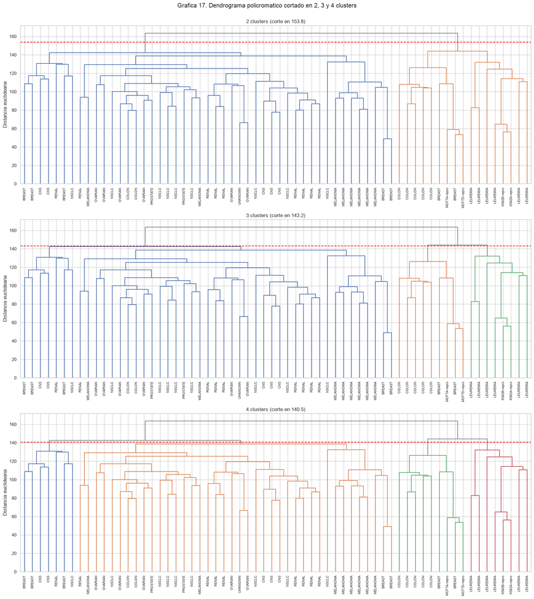

```python
#Codigo hecho con claude
alturas = hc_comp_euc[:, 2]
set_link_color_palette(['#4C72B0', '#DD8452', '#55A868', '#C44E52'])

fig, axes = plt.subplots(3, 1, figsize=(18, 20))
for ax, k in zip(axes, [2, 3, 4]):
    umbral = (alturas[-(k - 1)] + alturas[-k]) / 2
    graficar_dendrograma(hc_comp_euc, f'{k} clusters (corte en {umbral:.1f})', ax, 'Distancia euclideana', umbral=umbral)
    print(f"{k} clusters -> umbral {umbral:.1f}, tamanos: {np.bincount(fcluster(hc_comp_euc, k, criterion='maxclust'))[1:]}")
plt.suptitle('Grafica 17. Dendrograma policromatico cortado en 2, 3 y 4 clusters', y=1.0)
plt.tight_layout()
plt.show()
set_link_color_palette(None)
```

- **2 clusters** (corte en 153.8): un grupo de 47 y uno de 17 (leucemias, colon, réplicas de MCF7 y 2 de mama).
- **3 clusters** (corte en 143.2): el grupo de 17 se parte en dos: las 8 leucemias (con K562) y los 9 de colon y MCF7. El grupo de 47 se queda igual.
- **4 clusters** (corte en 140.5): ahora se parte el grupo grande, en uno de 7 (3 de mama, 2 del sistema nervioso, 1 renal y 1 de pulmón) y uno de 40.

Aquí se ve por qué se le llama **jerárquico**: al bajar el corte los clusters nunca se reacomodan, solo se parten en dos. Los 4 clusters están anidados dentro de los 3, y los 3 dentro de los 2. Además, con un solo árbol tenemos la respuesta para 2, 3 o 4 clusters sin volver a correr nada; con K-means habría que correr el algoritmo una vez por cada $K$.

## 3.5 Método complete con métrica de correlación

Ahora se repite el proceso cambiando solo la métrica a `'correlation'`. Como en el ejemplo de H-E-B, la distancia de correlación no se fija en qué tan altos o bajos son los valores, sino en si dos líneas celulares tienen el mismo **patrón**: los mismos genes arriba del promedio y los mismos abajo. La distancia de correlación es $1 - r$, así que va de 0 (perfil idéntico) a 2 (perfil opuesto).

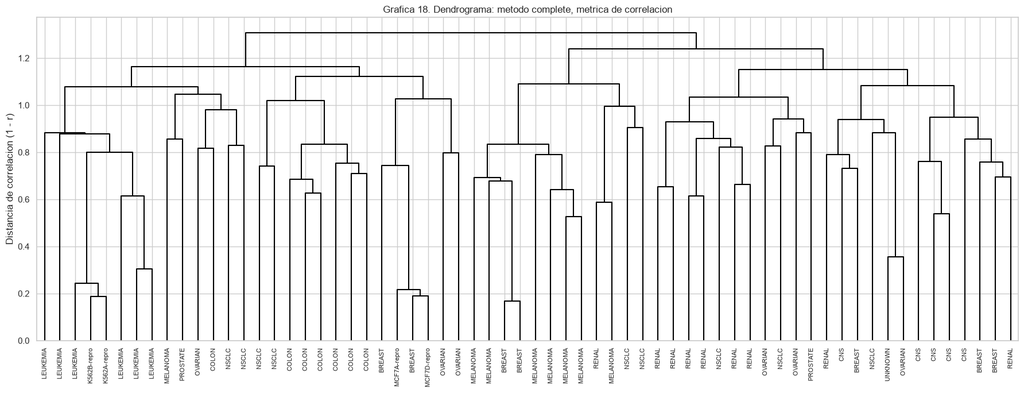

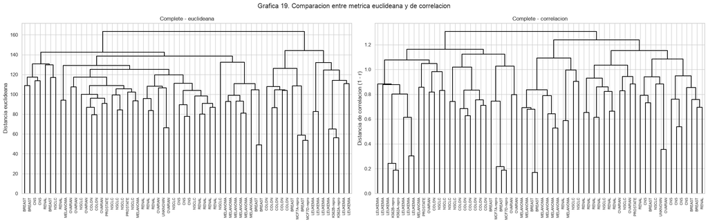

```python
#Codigo hecho con claude
hc_comp_cor = linkage(datos_esc, method='complete', metric='correlation')

fig, ax = plt.subplots(figsize=(18, 7))
graficar_dendrograma(hc_comp_cor, 'Grafica 18. Dendrograma: metodo complete, metrica de correlacion', ax, 'Distancia de correlacion (1 - r)')
plt.tight_layout()
plt.show()

fig, axes = plt.subplots(1, 2, figsize=(22, 7))
graficar_dendrograma(hc_comp_euc, 'Complete - euclideana', axes[0], 'Distancia euclideana')
graficar_dendrograma(hc_comp_cor, 'Complete - correlacion', axes[1], 'Distancia de correlacion (1 - r)')
plt.suptitle('Grafica 19. Comparacion entre metrica euclideana y de correlacion')
plt.tight_layout()
plt.show()
```

- **La escala cambia:** con distancia euclideana las uniones llegan hasta 163; con correlación la distancia es $1 - r$, que va de 0 a 2, y aquí la unión más alta es alrededor de 1.3. Las alturas no se pueden comparar entre los dos dendrogramas, solo la forma del árbol.
- Las **réplicas** se siguen uniendo hasta abajo (alrededor de 0.2), igual que antes: tienen casi el mismo perfil genético.
- La estructura de arriba cambia bastante. Con correlación, la primera separación deja de un lado a leucemia, colon y las réplicas de MCF7 (con algunos de pulmón, ovario y próstata), y del otro a melanoma, renal y sistema nervioso.
- Los grupos quedan **más balanceados** que con la euclideana, y aparece una rama a la derecha que junta a casi todos los **renales** con los del **sistema nervioso**, cosa que no pasaba con la distancia euclideana. Las leucemias, los de colon y los melanomas siguen formando sus propias ramas.

Esto pasa porque, como en el ejemplo de H-E-B, la correlación no se fija en si una línea celular tiene niveles de expresión altos o bajos en general, sino en **qué genes** tiene arriba y abajo de su propio promedio. Para datos de expresión genética esto suele tener más sentido biológico: dos tumores del mismo tipo activan los mismos genes, aunque la medición de uno salga en general más alta que la del otro.

## 3.6 Método average con métrica euclideana

Por último se cambia el método de *linkage* a `'average'` (con métrica euclideana otra vez). Con *complete* la disimilitud entre dos clusters es la **más grande** entre sus miembros; con *average* es el **promedio** de todas las disimilitudes entre los miembros de los dos clusters.

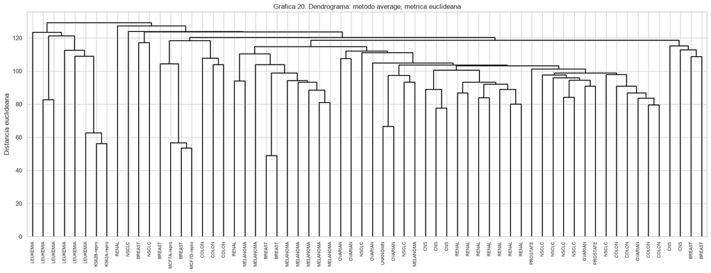

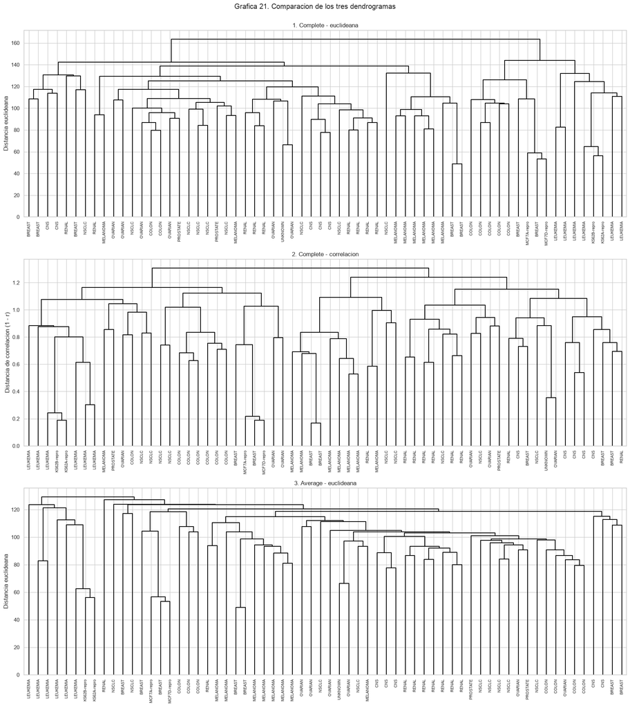

```python
#Codigo hecho con claude
hc_avg_euc = linkage(datos_esc, method='average', metric='euclidean')

fig, ax = plt.subplots(figsize=(18, 7))
graficar_dendrograma(hc_avg_euc, 'Grafica 20. Dendrograma: metodo average, metrica euclideana', ax, 'Distancia euclideana')
plt.tight_layout()
plt.show()

fig, axes = plt.subplots(3, 1, figsize=(18, 20))
graficar_dendrograma(hc_comp_euc, '1. Complete - euclideana', axes[0], 'Distancia euclideana')
graficar_dendrograma(hc_comp_cor, '2. Complete - correlacion', axes[1], 'Distancia de correlacion (1 - r)')
graficar_dendrograma(hc_avg_euc, '3. Average - euclideana', axes[2], 'Distancia euclideana')
plt.suptitle('Grafica 21. Comparacion de los tres dendrogramas', y=1.0)
plt.tight_layout()
plt.show()
```

El dendrograma con *average* se ve muy distinto a los de *complete*:

- Tiene forma de **escalera**: en vez de juntar grupos de tamaños parecidos, va pegando una o dos observaciones a la vez a un grupo grande que no deja de crecer. A esto se le llama encadenamiento (*chaining*).
- Las 8 leucemias siguen saliendo como un grupo aparte, pero si se corta el árbol en pocos clusters, casi todo lo demás queda en un solo grupo enorme y algunos "clusters" son una sola línea celular que se une con el resto hasta el final.
- Con *complete* pasa lo contrario: como usa la disimilitud **más grande** entre los miembros de los dos clusters, un grupo solo se une con otro cuando **todos** sus miembros están razonablemente cerca, y eso da clusters más compactos y balanceados. Con *average*, una observación rara que está lejos de todas se queda sola hasta muy arriba, porque su distancia promedio a cualquier grupo es alta, mientras que el grupo grande va absorbiendo a las demás.

En este dataset *complete* dio los grupos más fáciles de interpretar, y la métrica de correlación encontró grupos que la euclideana no veía. Esto muestra que en clustering jerárquico la métrica y el método de *linkage* no son detalles: cambian el resultado.